# R workshop

MTRabanusWallace

04/01/2017

# Introduction

R is the world’s most popular (and best) statistical programming language. Open source and hugely community-driven, and is constantly expanded by the development of *packages* that add new functionality and implement new analysis methods and tools. New packages are added to the official curated package database *CRAN* every week.

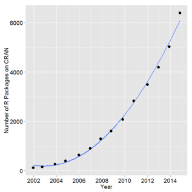

Thanks to this flexibility, useability, and speed, R’s popularity has exploded in the last decade, especially in bioinformatics.

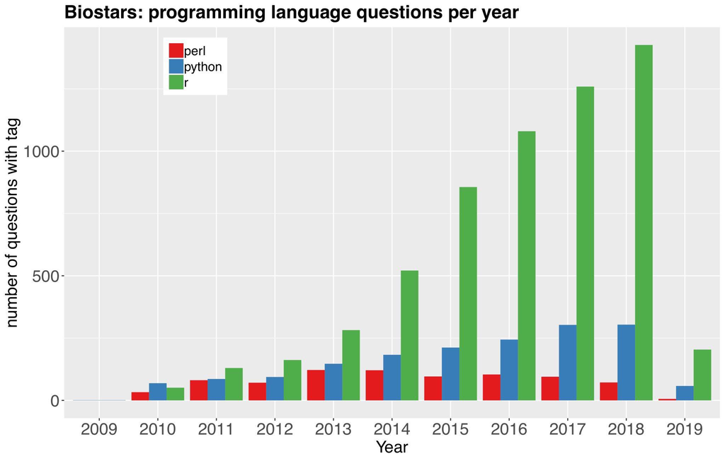

This session should set you up with the R skills to do analysis on biological data. In a few hours, you can challenge yourself to undertand a line of code like this:

```
data[ !is.na(genotype)  ,  .(  n_SNPs=.N  ,  n_homozygotes=sum( genotype==0 || genotype==1 )  )  ,  by=.(sample) ]
```

We will use R via an *Integrated Development Environment* or IDE, called Rstudio. It’s a nice visual tool that puts everything you need to know on one screen and makes programming much easier.

# Getting started with the IDE

To begin with, use the `library()` function to load up the day’s required packages and set your working directory; Copy-paste these commands to the top of your script.

```r
setwd("/home/username/workspace") #enter your username
source("bin/tim_functions.R")
source("bin/course_functions.R")
library(magrittr)
library(data.table)
library(ggplot2)
library(dplyr)
library(plyr)
library(parallel)
library(bnstruct)
library(SNPRelate)
```

The lower left panel is the *console*, which is where you run R commands interactively. Run a simple arithmetic operation by typing `1+1` into the console and pressing enter. If the answer isn’t `2` there’s something very wrong with the universe.

More usually, you’ll want to write commands into the script and run them in the console. Rstudio makes this easy. Copy these simple arithmetic operations into your script:

```r
1+1
1-1
5*5
4**2 #four to the power of two
log10(1e6) #the log (in base 10) of 1 million
```

As you can see, the hash `#` also indicates comments in R, just as it did in Bash.

Also similar to Bash’s command “man”, you can ask for information about many R functions with by entering the command preceded by a question mark

```r
?sum
```

# The Amazing data.table

A `data.table` is one of the most useful data structures in statistical programming. They are very much like typical Microsoft Excel spreadsheets, where you might have rows representing experimental ‘units’ (observations, SNPs, plants, subjects, measurements … ).

Let’s dive in with some pretend data that looks almost identical to real genetics data. Generate some trial data using this command (which you may like to try interpreting for yourself as homework). We’re going to pretend each row is a SNP position in the genome of some individual. We’ll have a column for the sample name, the SNP position, the genotype ( 0=reference allele; 1=heterozygote; 2=alternative allele, NA=missing data ), and a genotype quality score:

```r
#this is the data.table contructor function. You don't need to understand all the functions inside it
data <- data.table(
  sample = paste0("Sample_", rep(x=1:4,each=5) ),
  pos = rep(c(136,1043,1599,2102,3652),times=4) ,
  genotype = c(0,0,1,2,2,2,NA,0,2,1,0,0,1,1,1,NA,2,1,1,0) ,
  genotype_quality = runif(20,min=10,max=100) %>% round(digits=0) %>% as.integer
)
```

We can see the contents of our data.table by just running its name.

```r
data
```

[figure not shown]

So it looks like a nice neat spreadsheet, and it represents a dataset of SNP calls, where each sample has a genotype call (0, 1, or 2) at each position (pos). And there’s also a column of quality scores for the genotype calls.

## The three indexing fields

data.table’s power lies largely in its excellent *indexing* system. data.tables have three indexing fields that perform these three functions. Remember this basic structure:

> data_table[ SELECT , DO_SOMETHING , GROUP_BY ]

When you start writing a data.table command, just start with `data[ , , ]`, and fill in the fields later. You can leave fields blank too.

### 1) The SELECT field.

This is used to select certain rows, and we do that by making logical statements about the columns, for instance:

```r
data[ pos > 2000 , , ]
```

This selects all the rows where pos is above 2000.

Here’s another example.

```r
data[ sample=="Sample_1" , , ]
```

Selects rows where the sample is “Sample_1”.

These kinds of statements are called “logical tests”. `==` is just one such logical test, it compares things to see if they are the same. Just like in english, concepts like “and” and “or” are really useful logical tools. In R, “and” is `&` and “or” is `|`. For instance, we can select rows where pos is above 2000 AND the sample is “Sample_1”.

```r
data[ pos > 2000 & sample=="Sample_1" , , ]
```

A good way to visualise selection is that is just crosses out rows that fail the logical tests, like this.

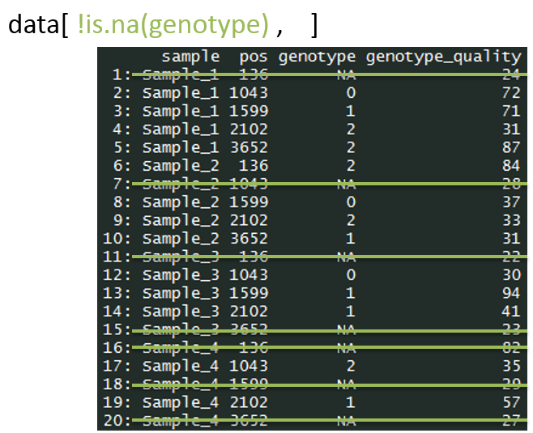

#### Exercises:

1. Select all the rows of `data` where the position is below 1000
2. Use the OR operator `|` to select all the rows where the position is below 1000, OR the genotype_quality is above 30
3. Select all the rows where the position is between 1000 and 2000
   - HINT: Use the AND operator `&`

Here are some more logical operators:

“not” in R-speak is `!`, and it always goes BEFORE the logical test. We can select all the rows where the sample is NOT “Sample_1”.

```r
data[ !sample=="Sample_1" , , ]
```

The function `is.na()` tests whether an entry is “missing”, or NA. We can select rows where the genotype call is missing like this:

```r
data[ is.na(genotype) , , ]
```

#### Exercises:

- Select rows of data where the genotype is NOT missing.
- Select rows of data where the genotype is heterozygous (1).
  - HINT: Use `==`.
- Using the NOT operator `!`, select rows of data where the genotype is NOT heterozygous (1).
  - BONUS: Work out how to do the same selection using the *not equals* operator, which is `!=`.

### 2) The DO_SOMETHING field.

The DO_SOMETHING field is for when you don’t just want to filter the table, you want to perform functions on the columns.

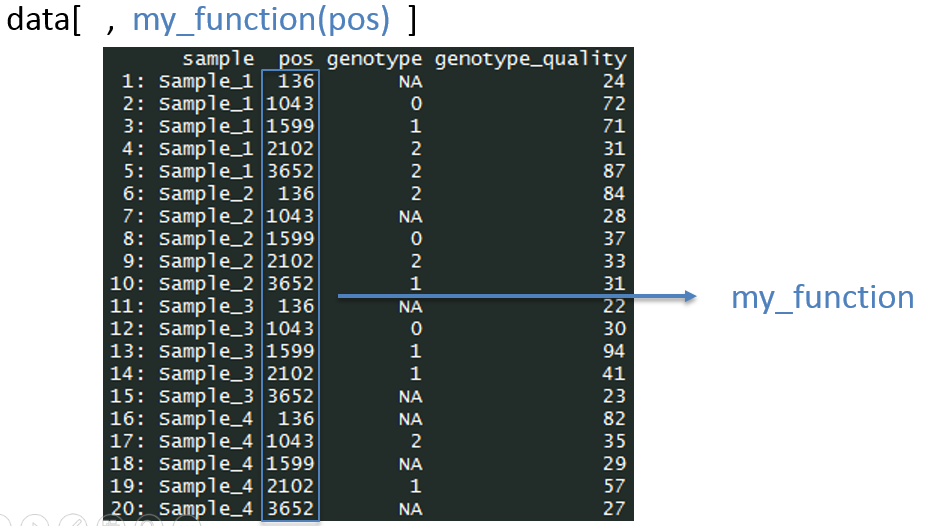

Some common functions are things like “sum()” which adds up the numbers in a column, or “max()” and “min()” which get the maximum or minimum of a column, or “mean()” which takes the average of a column.

```r
data[ , max(genotype_quality)  , ]
data[ , min(genotype_quality)  , ]
data[ , mean(genotype_quality) , ]
data[ , max(pos) , ]
```

And this can be combined with the select field

```r
data[ sample=="Sample_1" , max(genotype_quality)  , ]
data[ pos < 1000 , min(genotype_quality)  , ]
```

#### Exercise

- Calculate the average (mean) genotype_quality for rows where the sample is NOT “Sample_2”

#### Returning multiple results from DO_SOMETHING

```r
data[ ,  .(  mean_gq=mean(genotype_quality)  ,  max_gq=max(genotype_quality)   ) ,  ]
```

#### Modifying the original data.table with `:=`

Often, you want to actually change the data.table, for instance, changing the values inside columns, or adding a new column. The DO_SOMETHING field gives you access to the *modification operator* `:=` for just this purpose.

```r
#first, select rows with low genotype_quality, and change those genotypes to NA
data
data[ genotype_quality < 30  , genotype := NA ]
data

#use the modify operator to add a new column
data[  , genotype_quality_plus_1000 := genotype_quality+1000 ]
data #now we have a new column
```

Finally, data.table has a “special” variable, `.N`, which just gives you back the number of rows.

```r
data[ , .N , ]
data[ genotype_quality < 30  , .N ]
```

#### Exercise

1. Using `data`, select all the columns with position < 2000, and return three columns:
   - A column called “mean_gq”, with the mean genotype_quality, and
   - A column called “nrows” with the number of rows.
   - A column called “pos_plus_gq” with the pos plus the genotype_quality
   - HINT: Use the `.( column1_name= ... , column2_name= ... )` structure in the DO_SOMETHING field
   - HINT: Try returning just one of the columns first, then expand the command to include the next, and the next.
   - HINT: Remember, `.N` gives you the number of rows.

### 3) The GROUP_BY field.

As it suggests, GROUP_BY lets us divide the data.table up into groups and do our DO_SOMETHING operations in each group separately. We use it by writing “by=.(COLUMN)”, where the COLUMN will be used to divide the table into groups.

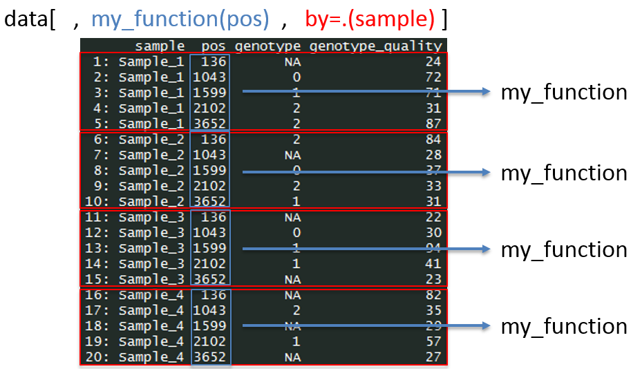

And we can then do all the same things with SELECT and DO_SOMETHING … but they will be done separately on each group. Take this example:

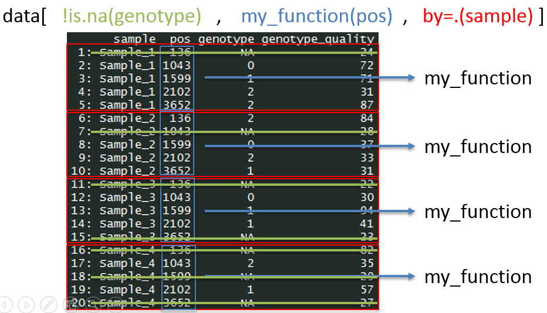

Great if you want, for instance, to run a procedure on each SNP, say, getting the average quality at each SNP position.

```r
data[ , mean(genotype_quality) , by=.(pos) ]
```

Or we could use the `.N` variable to count the rows in various groupings. Here, we count the number of heterozygote calls (genotype==1) for each sample …

```r
data[ genotype==1 , .N , by=.(sample) ]
```

Finally, try this exercises that combines all three of these ideas: SELECT, DO_SOMETHING, and GROUP_BY.

#### Exercise:

- Count the number of genotypes that are not “NA” for each sample
  - HINT: Start by filling the SELECT field to select the rows you want. Once that’s working, fill the DO_SOMETHING field to count the rows. Once that works, fill the GROUP_BY field to do the counting separately for each sample.

## Assigning data.tables to new variables

If we want to save the results of our work to a new data.table, we just assign the result to a variable. In Bash we used `=` for assignment, but in R we use `<-`.

For example, we can make a new data.table with only rows where pos is below 1000.

```r
data_pos_below_1000 <- data[ pos < 1000 ,  , ]

#print out the new data table
data_pos_below_1000
```

## Extracting columns of a data.table

If we did something useful such as making a data.table with only genotype_quality above a certain level, we often want to produce a “list” of, say, the positions of those SNPs.

We can do this simply by providing the column name in the DO_SOMETHING field, or we can use the handy dollar sign operator:

```r
#these do the same thing
data[ genotype_quality > 50 , pos , ]
data[ genotype_quality > 50 ]$pos
```

These “lists” are called *vectors*. We can save them in variables just like anything else.

```r
positions <- data[ genotype_quality > 50 ]$pos

positions
```

There are lots of R functions that work on vectors, for example, try these:

```r
sum(positions)
mean(positions)
sd(positions) #use '?sd' if you want to know what it does!
unique(positions)
length(positions)
length(unique(positions))
```

As you can see, some of these functions are the same that we used on data.table columns. So let me tell you a secret: The columns of a data.table *are* actually just vectors, packaged together into a more useful structure.

So, we can also ask logical questions about vectors like we did in the select column, and we will get TRUE/FALSE answers for each item in the vector.

```r
positions > 2000
```

And we can even count the number of “TRUE”s using sum()

```r
sum ( positions > 2000 )
```

There’s a bit more functionality to `data.table`s we’ll pick up later, but the most important things are now covered.

# Plotting with ggplot

Last of all for this session, we’ll learn the very basics of making scatterplots with the package `ggplot2`. This package works wonderfully with data in `data.frame` type formats.

A typical ggplot2 call for a scatterplot looks like this:

> ggplot( data=DATA_TABLE , mapping=aes( x=COLUMN_NAME_FOR_X_AXIS , y=COLUMN_NAME_FOR_Y_AXIS ) ) + geom_point()

You can copy/paste the above command to begin. Then:

1. Replace “DATA_TABLE” with the data.table you want to plot from (in this case, `data`)
2. Replace COLUMN_NAME_FOR_X_AXIS with the column name in the data.table that should tell the points where to go on the x-axis
3. Replace COLUMN_NAME_FOR_Y_AXIS with the column name in the data.table that should tell the points where to go on the y-axis
4. Run the command!

Try this command where we put the samples on the y axis and positions on the x axis.

```r
ggplot( data=data , mapping = aes( x=pos , y=sample ) ) + geom_point()
```

So that’s the basic idea. It gets interesting when we start using more columns to add more visual information. For instance, besides just `x=` and `y=`, we can select columns to set the colour or the shape of the points.

```r
ggplot( data=data , mapping = aes( x=pos , y=sample , colour=genotype ) ) + geom_point()
```

To get a discrete colour scale (so, red, blue, green etc, instead of shades of blue), just surround the column name by “as.factor()” like this:

```r
ggplot( data=data , mapping = aes( x=pos , y=sample , colour=as.factor(genotype) ) ) + geom_point()
```

# The custom function `%>% pd`

As your R usage grows you’ll start writing your own functions to do things you find convenient. I have one called `pd` meaning “plot density”, which we will use today as a super fast way to look at how data are spread out. It works wonderfully with R’s verison of the pipe operator (“remember `|` from Bash?”), which looks like this: `%>%`. To get a feeling for it, let’s look at some normally distributed random data:

```r
rnorm(5) #this generates five random numbers from a standard normal distribution
rnorm(5) %>% pd
rnorm(100) %>% pd
rnorm(10000) %>% pd
rnorm(1000000) %>% pd
```

As you can see, we get a very intuitive density plot of the data, which is very useful in bioinformatics. For instance, we can as what the spread of genotype_qualities is like.

```r
data$genotype_quality #extracts the column as a vector

data$genotype_quality %>% pd
```

pd() has one optional setting `bw` that can be adjusted to set the “smoothness” as needed:

```r
rnorm(100,10,4) %>% pd(bw=.1)
rnorm(100,10,4) %>% pd(bw=.5)
rnorm(100,10,4) %>% pd(bw=1)
rnorm(100,10,4) %>% pd(bw=2)
```

# Practise exercises

Using `data` …

1. Use the help feature `?` to find out what the function `paste()` does.
2. Using paste, create a new column in ‘data’ called “pos_and_genotype”, which contains the position followed by the genotype.
   - HINT: We add columns with `:=`, as in `data[ , new_column_name := ... , ]`
   - HINT: The paste command will be like this: `paste(pos,genotype)`
3. Make a scatterplot of the data with genotype on the x-axis and genotype_quality on the y-axis
   - BONUS: Change the size of the points to 0.2
   - BONUS: Colour the points according to the sample
4. Extract the column “genotype” and save the vector in a variable called “genotypes”.
   - BONUS: Do it two different ways
5. Take the sum of the vector genotypes (it will say “NA”)
6. Use the help documentation for `sum` (or Google) to find out how to make `sum` ignore NAs (using `na.rm`)